# Trabajo de Fin de Máster

### Máster Big Data y Data Science 2021-2022

## Introducción

En el contexto del Máster Big Data y Data Science se presenta a continuación el notebook correspondiente al Trabajo de Fin de Máster. El mismo se ha realizado siguiendo la consigna 1 de la "Guía para realizar el trabajo de fin de máster": Análisis de un dataset. El dataset elegido es Fake News, obtenido de Kaggle. (https://www.kaggle.com/competitions/fake-news).

### Dataset

El dataset es una colección de noticias ya etiquetadas como falsas(1) o verdaderas(0). Los campos son ('título', 'autor', 'cuerpo') El cuerpo será llamado también 'texto' de la noticia..

### Objetivo

- Obtener un modelo de Machine Learning o Deep Learning que permita distinguir fake news, previo análisis e ingeniería de variables.
- Crear una función de predicción que permita pasarle nuevas news al modelo para obtener la predicción correspondiente.

### Alcance

El presente notebook es el resultado final obtenido luego de realizar diversos análisis y experimentos. No se pretende mostrar el proceso exploratorio completo que fue llevado a cabo para la obtención de las variables y de los modelos finales. Sino mas bien, el informe buscará presentar el proceso directo de:

- Análisis
- Ingeniería de variables
- Modelado
- Producción

### Acerca del informe

El presente informe está basado en el **notebook** correspondiente que se puede encontrar en el siguiente link:

- https://colab.research.google.com/drive/1wQliwRGDaMBMYmGuavuDxK3wf0GrQju9?usp=sharing

Vale aclarar que los chunks en este informe no son presentados en el orden correspondiente a la ejecución de los mismos. Esto es para atender a la practicidad de la lectura del informe. En el Anexo se encontrarán las partes del código complementarias que han sido consideradas no relevantes al informe en sí. El código, ordenado, y comentado, se puede enconrar en el link indicado anteriormente.

El informe busca ser leído intercalando chunks y texto. Todo el código ha sido comentado para su facilitar su lectura.

La **presentación** utilizada para el video que acompaña esta entrega está en este link:

- https://app.mural.co/invitation/mural/tfm1429/1662562190866?sender=uc9502e6c09c1de19e4483866&key=d36a3fc9-5bc6-431d-a765-8caa5eebced5

El **video** que acompaña esta entrega se puede ver en el siguiente link:

- https://youtu.be/nvaC-WFN1xw

## Desarrollo

A continuación se presenta el código relevante a fines del informe. El mismo ha sido comentado e intercalado con texto para su lectura.

Las importaciones y funciones definidas para el desarrollo del trabajo están en el Anexo.

### Exploratory Analysis and Preprocessing

El análisis exploratorio se realiza en conjunto con el preprocesado. Ya que el dataset contiene tres variables(text, autor, título), la parte exploratoria en sí de estas features no es lo más relevante.

Básicamente, luego de un primer acercamiento al dataset (Raw Analysis), completar nulos y remover duplicados se realiza un preprocesado de **title** y **text** que incluye los siguientes pasos:

1. Convertir texto a minúsculas
2. Tokenizar
3. Quitar stopwords
4. Quitar signos de puntuación

Luego se agregan variables relevantes al dataset. Este proceso supuso una serie de iteraciones que caen fuera del alcance de este trabajo y se excluyen del mismo. Se presenta el proceso de creación de estas variables relevantes.

Las variables que se crean son:

- **Longitud de text**: cantidad de tokens de text. Se aplica luego del punto 4 del preprocesado detallado arriba.
- **Longitud de title**: cantidad de tokens de title. Se aplica luego del punto 4 del preprocesado detallado arriba.

*Para estas dos variables, luego de un análisis de outliers según la regla del diagrama de caja y bigotes se removieron ciertos valores. Las distribuciones de fake news y non fake news no eran parejas en estas variables. Siendo ambas predictores relevantes, se decidió remover outliers que hubieran sesgado el modelo.*

- **Polaridad y Subjetividad para text**. Se utilizó TextBlob para calcular ambos features.
- **Polaridad y Subjetividad para title**. Se utilizó TextBlob para calcular ambos features.
- **Spellcheck para text y para title**. Se utilizó TextBlob para calcular ambos features. Este feature se calcula promediando la confianza del primer item de la tupla (palabra, confianza) que devuelve la función spellcheck de cada una de las palabras preprocesadas de cada noticia. Es decir, para una noticia, se toma para cada palabra el primer itema de confianza, y luego se realiza el promedio de los mismos para cada noticia. El resultado es el valor del feature para esa noticia.

Se continua el preprocesado lematizando con Spacy.

Para completar el preprocesado, se realiza un fill de valores nulos.

Adicionalmente se han presentado dos WordClouds, para text y para title con las 100 palabras más importantes según el vector TFIDF.

#### Primer Análisis

Ver en Anexo.

#### Preprocesamiento del cuerpo de la noticia. Agregado de features.

```python
# preprocessing news's text
text_tkn = [minusculas(i) for i in tr['text']] # lowercase news's text
text_tkn = [tokenize(i) for i in text_tkn] # tokenize news's text
text_tkn = [quitar_stopwords(i) for i in text_tkn] # removing stopwords from news's text
text_tkn = [quitar_puntuacion(i) for i in text_tkn] # removing all but alphanumerical characters from news's text

# adding the processed text column to the dataset
tr['txt_preproc'] = text_tkn

# adding preprocessed news's text length column
tr.reset_index(inplace = True)
length = list()
for i in range(len(tr.txt_preproc)):
  length.append(len(tr.txt_preproc[i]))
tr['length_proc'] = length

# adding news's text length column
length = list()
for i in range(len(tr)):
  length.append(len(tr.text[i]))
tr['length'] = length
```

##### Plots y Outliers de Text Length.

El manejo de los outliers se encuentra desarrollado completo en el Anexo. A continuación se presenta un resumen para mostrar cómo se decidió manejarlos.

Se observa que las distribuciones de length para fake y non fake no son parejas para valores mayores que el bigote.  
Para evitar sesgos en el modelo, se busca emparejar las distribuciones.

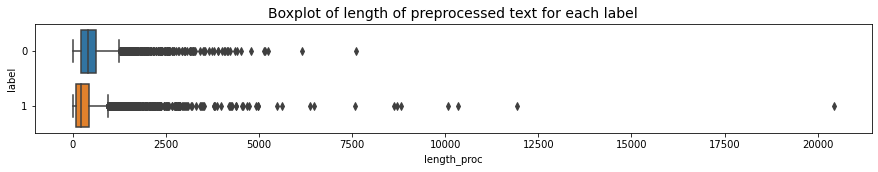

```python
sb.boxplot(x = "length_proc", y = "label", data = tr, orient = "h")
plt.title("Boxplot of length of preprocessed text for each label",fontdict={'fontsize':14})
plt.gcf().set_size_inches(15, 2)
```

Visualización de la posición relativa de cada uno de los bigotes.

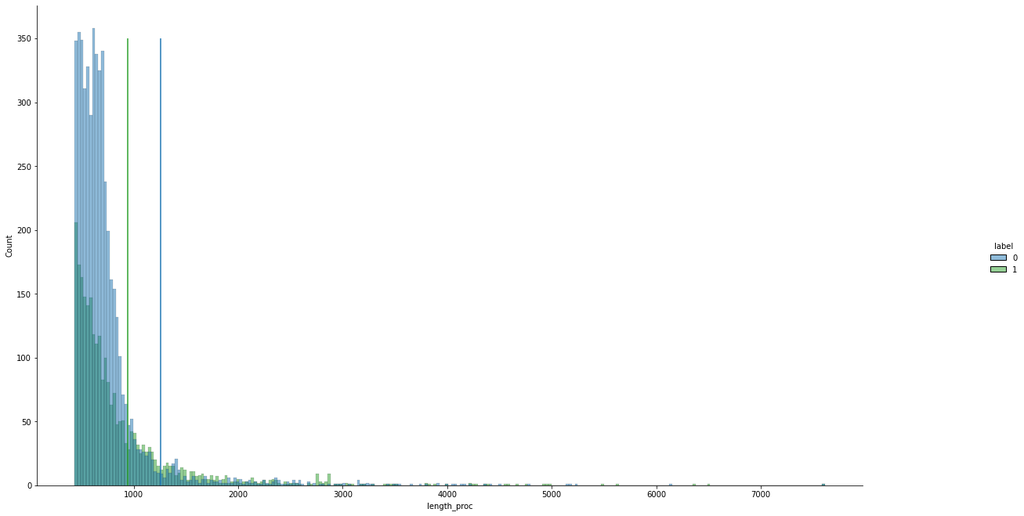

```python
max0 = max(tr.query('label == 0')['length_proc'])
q = np.percentile(tr.query('label == 1')['length_proc'],75)
data = tr[(tr['length_proc'] >= q) & (tr['length_proc'] <= max0)]

p = sb.displot(x = "length_proc", data = data, hue = "label", palette = ('C0', 'C2'))
plt.vlines(x = q3_0 + 1.5*(q3_0-q1_0), ymin = 0, ymax = 350, colors = 'C0')
plt.vlines(x = q3_1 + 1.5*(q3_1-q1_1), ymin = 0, ymax = 350, colors = 'C2')

plt.gcf().set_size_inches(20, 10)
```

El valor más alto será utilizado como cota superior para dividir outliers.  
Todas las noticias cuya longitud de texto preprocesado sea mayor que el valor tomado como cota superior será eliminado por ser outlier.  
Pero primero, se comprobará que los outliers no sean mas del 5% del dataset.

```python
whisk0 = q3_0 + 1.5*(q3_0-q1_0) # the greatest whisker is for NON fake news

# total news with preprocessed text length greater than the greatest whisker
outofw = len(tr.query('length_proc >= @whisk0'))

# total NON fake news with preprocessed text length greater than the greatest whisker
outofw0 = len(tr[(tr['label'] == 0) & (tr['length_proc'] >= whisk0)])

# total fake news with preprocessed text length greater than the greatest whisker
outofw1 = len(tr[(tr['label'] == 1) & (tr['length_proc'] >= whisk0)])

count0 = len(tr.query('label == 0')['length_proc']) # total NON fake news
count1 = len(tr.query('label == 1')['length_proc']) # total fake news
count = len(tr) # total news

print("Total outliers vs total news: ", outofw/count)
print("Total NON fake news outliers vs total NON fake news: ", outofw0/count0)
print("Total fake news outliers vs total fake news: ", outofw1/count1)
```

```
Total outliers vs total news:  0.03025470011115944
Total NON fake news outliers vs total NON fake news:  0.02618657937806874
Total fake news outliers vs total fake news:  0.0343555900621118
```

##### Eliminación de outliers y visualización de las distribuciones emparejadas.

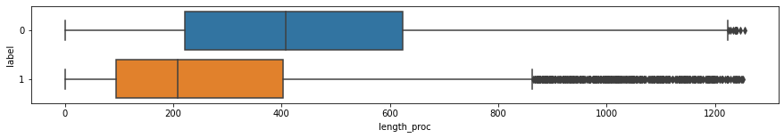

```python
sb.boxplot(x = "length_proc", y = "label", data = tr, orient = "h")
plt.gcf().set_size_inches(15, 2)
```

#### Preprocesamiento del título de la noticia. Agregado de features.

```python
# preprocessing news's title
title_tkn = [minusculas(i) for i in tr['title']] # lowercase the news's title
title_tkn = [tokenize(i) for i in title_tkn] # tokenize the news's title
title_tkn = [quitar_stopwords(i) for i in title_tkn] # removing news's stopwords
title_tkn = [quitar_puntuacion(i) for i in title_tkn] # remvoving all but alphanumeric characters from news's title

# adding the processed title column to the dataset
tr['ttl_preproc'] = title_tkn

# adding processed title length column to the dataset
title_length = list()
for i in range(len(tr)):
    title_length.append(len(tr['ttl_preproc'][i]))
tr['length_ttl'] = title_length
```

##### Plots y Outliers de Title length.

El manejo de los outliers se encuentra desarrollado completo en el Anexo. A continuación se presenta un resumen para mostrar cómo se decidió manejarlos.

Se observa que las distribuciones no son parejas.  
Se buscará definir una cota superior para delimitar outliers.

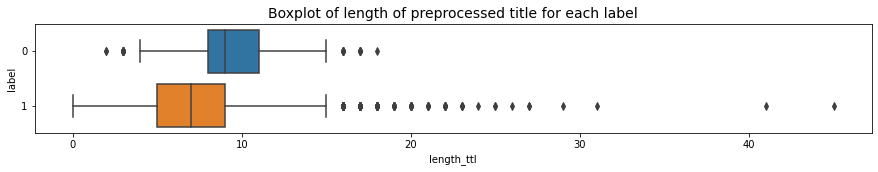

```python
sb.boxplot(x = "length_ttl", y = "label", data = tr, orient = "h")
plt.title("Boxplot of length of preprocessed title for each label",fontdict={'fontsize':14})
plt.gcf().set_size_inches(15, 2)
```

El valor máximo de NON Fake News será utilizado como cota superior para delimitar outliers.  
Todos los datos cuya longitud de título preprocesado sea mayor que esta cota serán eliminados por ser outliers.

```python
max1 = max(tr.query('label == 0')['length_ttl'])
max1, len(tr.query('length_ttl > @max1'))
```

```
(18, 53)
```

##### Eliminación de outliers y visualización de distribuciones emparejadas.

```python
max1 = max(tr.query('label == 0')['length_ttl'])
tr = tr.query('length_ttl <= @max1').copy()
```

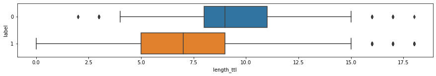

```python
sb.boxplot(x = "length_ttl", y = "label", data = tr, orient = "h")
plt.gcf().set_size_inches(15, 2)
```

#### Sentiment Analysis

##### Se agrega polaridad y subjetividad para title y text.

Se computan de los strings sin procesar

```python
# subjectivity and polarity for news's title
ttl_subjectivity = tr['title'].apply(lambda x: TextBlob(x).sentiment.subjectivity)
ttl_polarity = tr['title'].apply(lambda x: TextBlob(x).sentiment.polarity)

# subjectivity and polarity for news's text
txt_subjectivity = tr['text'].apply(lambda x: TextBlob(x).sentiment.subjectivity)
txt_polarity = tr['text'].apply(lambda x: TextBlob(x).sentiment.polarity)

# adding the features to the dataset
tr['ttl_subjectivity'] = ttl_subjectivity
tr['ttl_polarity'] = ttl_polarity
tr['txt_subjectivity'] = txt_subjectivity
tr['txt_polarity'] = txt_polarity
```

##### Plots

Ver en Anexo.

#### Lematización

Se utiliza Spacy para lematizar título y texto preporcesados de cada noticia

```python
nlp = spacy.load('en_core_web_sm', disable=['parser', 'ner']) # loading spacy lemmatizer
txt_lemm = tr.txt_preproc.apply(lematizar) # lemmatizing the news's text applying the function lematizar
ttl_lemm = tr.ttl_preproc.apply(lematizar) # lemmatizing the news's title applying the function lematizar
tr['ttl_lemm'] = ttl_lemm # adding the lemmatized title feature to the dataset
tr['txt_lemm'] = txt_lemm # adding the lemmatized text feature to the dataset
```

#### Spellcheck

Se utiliza TextBlob para realizar spellcheck de texto y título.  
La función devuelve la media de la confianza de la primer tupla de cada palabra.  
Importante:

- el spellcheck se aplica a texto y título preprocesado. El preprocesado incluye: convertir a minúsculas, quitar stopwords, signos de puntuación y tokenizado.
- el spellcheck se aplica a una muestra aleatorio del 10% de la lista de palabras. Esto por un tema de tiempos de ejecución. Con este compromiso, el tiempo de ejecución del spellcheck es cercano a las 4 horas con la capacidad de cómputo disponible.

```python
txt_spellcheck = tr.txt_preproc.apply(spellcheck) # applying the spellcheck to the preprocessed text
```

```python
tr['txt_spellcheck'] = txt_spellcheck # adding the text spellcheck feature to the dataset
```

```python
ttl_spellcheck = tr.ttl_preproc.apply(spellcheck) # applying the spellcheck to the preprocessed title
```

```python
tr['ttl_spellcheck'] = ttl_spellcheck # adding the title spellcheck feature to the dataset
```

#### Nulos

Se realiza un chequeo de nulos para las features agregadas.  
Ver en Anexo.

```python
tr.to_csv('preprocessed_train.csv')
```

```python
tr.to_csv('/content/drive/MyDrive/preprocessed_train.csv')
```

#### Wordclouds

Se vectoriza con TFIDF para mostrar wordclouds con las palabras mas relevantes de title y text.  
Para vectorizar, se requiere transformar la lista de tokens preprocesados en strings.  
Ver en Anexo.

### Modeling

Se presenta a continuación los modelos más relevantes a los que se llegó luego de repetidos experimentos a través de los cuales se fueron no solo agregando variables sino también modificando hiperparámetros.

**Matriz de features**  
La matriz de features es un TFIDF para text, apilado con el TFIDF de title, y los feeatures numéricas creadas en la fase anterior.

Los parámetros para text son:

- min_df = 0.05
- max_df = 0.85
- ngram = (1,4)
- max_features = 4000

La matriz de titulos contiene menos features y de menor longitud. Los parámetros para title son:

- min_df = 0.0
- max_df = 1.0
- ngram = (1,4)
- max_features = 1000

Las variables numéricas agregadas son:

1. Processed text length
2. Processed title length
3. Text polarity
4. Text subjectivity
5. Title polarity
6. Title subjectivity
7. Text spellcheck
8. Title spellcheck

**Modelos**  
Dada la naturaleza del problema, una clasificación binaria con una gran cantidad de features, se eligen tres modelos que probaron dar buenos resultados como se ve en las matrices de confusión más abajo.

1. Neural Network

Se obtuvieron resultados satisfactorios con una red densa de 4 capas. Si bien se hicieron experimentos con CNN y RNN, los resultados más satisfactorios en cuanto a accuracy y cantidad de epochs se lograron con la red densa.  
Se invita a revisar todos los parámetros de la red más abajo. El valor más influyente que permitió elevar el accuracy por encima de 0.9 fue el optimizador Adam.

2. Logistic Regression

Se invita a revisar todos los parámetros más abajo. Este modelo se optimizó con un GridSearchCV obteniendo resultados similares a la de la red.

3. Random Forest

Se invita a revisar todos los parámetros más abajo. Este modelo fue el más intensivo computacionalmente. Definitivamente es el modelo que más tiempo tomó para su entretnamiento. Inicialmente se hizo un Random Search y luego un GridSearchCV obteniendo resultados similares a los dos anteriores.

Esta etapa se completa almacenando los modelos en forma persistente para luego ser utilizados en producción para predecir nuevas noticias.

```python
tr = pd.read_csv('/content/drive/MyDrive/preprocessed_train.csv', engine = "python", encoding='utf-8') # looading the dataset in the variable tr')
```

#### Vectorizado

Se elige el vectorizador TFIDF.  
Se vectorizan title y text.  
Los hiperparámetros mostrados fueron elegidos luego de varios experimentos.

```python
# vectorizing text
vectorizador_txt = TfidfVectorizer(min_df = 0.05, ngram_range = (1,4), max_df = 0.85, max_features = 4000)
vector_txt = vectorizador_txt.fit_transform(tr['txt_lema'].values.astype('U'))

# vectorizing title
vectorizador_ttl = TfidfVectorizer(min_df = 0.00, ngram_range = (1,4), max_df = 1, max_features = 1000)
vector_ttl = vectorizador_ttl.fit_transform(tr['ttl_lema'].values.astype('U'))
```

#### Construcción de lal matriz X y vector obejtivo y

Se construye la matriz de features X con los siguientes campos:

1. Text TF IDF vector
2. Title TF IDF vector
3. Processed text length
4. Processed title length
5. Text polarity
6. Text subjectivity
7. Title polarity
8. Title subjectivity
9. Text spellcheck
10. Title spellcheck

```python
# target
y = tr['label'].values.astype(np.float32)

# features to add to the model
extra_features = tr[[
    'length_proc','length_ttl',
    'ttl_subjectivity','ttl_polarity','txt_subjectivity', 'txt_polarity',
    'txt_spellcheck','ttl_spellcheck']]

X = sp.sparse.hstack((vector_txt,vector_ttl,extra_features.values),format='csr') # building the feature matrix X
X_columns=list(vectorizador_txt.get_feature_names_out())+list(vectorizador_ttl.get_feature_names_out())+extra_features.columns.tolist()

X_train, X_test, y_train, y_test = train_test_split(X, y, random_state=0) # train test partition

# transforming sparse matrix to sparse tensor and then to dense vector for the Neural Network model
X_train = convert_sparse_matrix_to_sparse_tensor(X_train)
X_test = convert_sparse_matrix_to_sparse_tensor(X_test)
X_train = tf.sparse.to_dense(X_train, default_value=None, validate_indices=True, name=None)
X_test = tf.sparse.to_dense(X_test, default_value=None, validate_indices=True, name=None)
```

#### Neural Network

El tuning se excluye del alcance de este proyecto.  
Se muestra el mejor resultado obtenido luego de reptidos experimentos.  
El optimizador Adam fue el hiperparámetro más significativo para sobrepasar el 0.9 de accuracy.

```python
# building the model
es_callback = keras.callbacks.EarlyStopping(monitor='val_loss', patience=10, verbose=1)
custom_adam = keras.optimizers.Adam(learning_rate = 0.00001)
nn_model = tf.keras.models.Sequential(
    [
        keras.Input(shape = (X_train.shape[1])),
      # Dense
        layers.Dense(64, activation = 'relu'),
        layers.Dense(32, activation = 'relu'),
        layers.Dense(16, activation = 'relu'),
        layers.Dense(16, activation = 'relu'),
      # Out
        layers.Dense(1, activation = 'sigmoid')
    ]
)
```

```python
# compiling the model
nn_model.compile(loss = 'binary_crossentropy', optimizer = custom_adam, metrics = ['accuracy'])
```

```python
# fitting the model
fitting = nn_model.fit(X_train,
          y_train,
          epochs = 500,
          batch_size = 10,
          validation_split = 0.3,
          callbacks=[es_callback],
          verbose = 0)
```

```
Epoch 127: early stopping
```

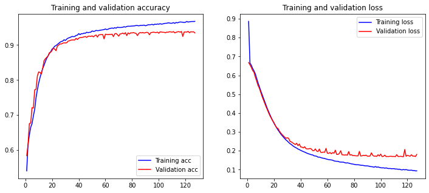

```python
# understanding losses and accuracy
plot_history(fitting)
```

```python
# visualizing the architecture
nn_model.summary()
```

```
Model: "sequential"
_________________________________________________________________
 Layer (type)                Output Shape              Param #
=================================================================
 dense (Dense)               (None, 64)                128832

 dense_1 (Dense)             (None, 32)                2080

 dense_2 (Dense)             (None, 16)                528

 dense_3 (Dense)             (None, 16)                272

 dense_4 (Dense)             (None, 1)                 17

=================================================================
Total params: 131,729
Trainable params: 131,729
Non-trainable params: 0
_________________________________________________________________
```

```python
results = nn_model.evaluate(X_test, y_test, verbose=0)
print('Test Loss: {}'.format(results))
```

```
Test Loss: [0.1724386066198349, 0.9378373026847839]
```

##### Confusion Matrix para Test

```python
y_classes = nn_model.predict(X_test).round()
print(confusion_matrix(y_test,y_classes))
print(classification_report(y_test,y_classes))
```

```
[[2350  212]
 [  99 2342]]
              precision    recall  f1-score   support

         0.0       0.96      0.92      0.94      2562
         1.0       0.92      0.96      0.94      2441

    accuracy                           0.94      5003
   macro avg       0.94      0.94      0.94      5003
weighted avg       0.94      0.94      0.94      5003
```

#### Machine Learning

##### Vectorizado

```python
# target
y = tr['label'].values.astype(np.float32)

# features to add to the model
extra_features = tr[[
    'length_proc','length_ttl',
    'ttl_subjectivity','ttl_polarity','txt_subjectivity', 'txt_polarity',
    'txt_spellcheck','ttl_spellcheck']]

X = sp.sparse.hstack((vector_txt,vector_ttl,extra_features.values),format='csr') # building the feature matrix X
X_columns=list(vectorizador_txt.get_feature_names_out())+list(vectorizador_ttl.get_feature_names_out())+extra_features.columns.tolist()

X_train, X_test, y_train, y_test = train_test_split(X, y, random_state=0) # train test partition
```

Se comparan tres modelos candidatos según su accuracy.  
Tanto LogisticRegression como DecisionTreeClassifier performan bastante similar, por ende se eligen para optimizar y comparar.  
Se muestran además ambas matrices de confusión.

```python
# candidate models
models = [ ("TreeClassifier", DecisionTreeClassifier()),
         ("Logistic",LogisticRegression(random_state=30)),
         ("GaussianNB",GaussianNB())]
# score
evaluation_score = "accuracy"
model_evaluation(models,  evaluation_score, X.toarray(), y)
```

```
Metric: accuracy , KFold
TreeClassifier: 0.881771 (0.006371)
Metric: accuracy , KFold
Logistic: 0.893763 (0.011647)
Metric: accuracy , KFold
GaussianNB: 0.807264 (0.012584)
```

```
([array([0.87562438, 0.88611389, 0.87906047, 0.88655672, 0.86656672,
         0.88455772, 0.88955522, 0.88255872, 0.88105947, 0.88605697]),
  array([0.8981019 , 0.8981019 , 0.87606197, 0.89205397, 0.87356322,
         0.89005497, 0.90054973, 0.89155422, 0.90254873, 0.91504248]),
  array([0.83766234, 0.8026973 , 0.7986007 , 0.80209895, 0.8015992 ,
         0.7966017 , 0.8165917 , 0.8115942 , 0.8135932 , 0.7916042 ])],
 ['TreeClassifier', 'Logistic', 'GaussianNB'])
```

##### LogisticRegression

```python
# creating the model and performing GridSearchCV
model = LogisticRegression()
solvers = ['newton-cg', 'liblinear','sag', 'lbfgs','saga']
penalty = ['l2']
c_values = [1000, 100, 10, 1.0, 0.1, 0.01, 0.001]
grid = dict(solver=solvers,penalty=penalty,C=c_values)
cv = KFold(n_splits=10)
grid_search = GridSearchCV(estimator=model, param_grid=grid, n_jobs=1, cv=cv, scoring='accuracy',error_score=0)
```

```python
# fitting GridSearch
grid_result = grid_search.fit(X_train, y_train)
C = grid_result.best_params_['C']
penalty = grid_result.best_params_['penalty']
solver = grid_result.best_params_['solver']
# training the model as per GridSearch results
model=LogisticRegression(C=C, penalty=penalty, solver = solver)
lr = model.fit(X_train,y_train)
# predicting
y_pred = lr.predict(X_test)
print(confusion_matrix(y_test,y_pred))
print(classification_report(y_test,y_pred))
print(lr.n_features_in_)
```

```
[[2401  161]
 [ 155 2286]]
              precision    recall  f1-score   support

         0.0       0.94      0.94      0.94      2562
         1.0       0.93      0.94      0.94      2441

    accuracy                           0.94      5003
   macro avg       0.94      0.94      0.94      5003
weighted avg       0.94      0.94      0.94      5003

2012
```

##### RandomForest

Dado que insume mucho tiempo de ejecución, se realiza un primer acercamiento con un random_grid search sobre un amplio rango de hiperparámetros.  
Luego, se realiza un GridSearchCV más ajustado, basándose en los parámetros del random_grid.  
Se computan las matrices de confusión para ambos modelos.

###### RandomSearch

Ver en Anexo.

###### GridSearch

Basado en los mejores parámetros de RandomSearch.

```python
rf_random.best_params_
```

```
{'n_estimators': 1400,
 'min_samples_split': 5,
 'min_samples_leaf': 1,
 'max_features': 'sqrt',
 'max_depth': 30,
 'bootstrap': True}
```

```python
# parameter grid based on the best parameters of random search
param_grid = {'bootstrap': [True],'max_depth': [40, 50],'max_features': ['sqrt'],
    'min_samples_leaf': [2, 3],'min_samples_split': [4, 6],'n_estimators': [1200, 1600]}

# grid search
rf = RandomForestClassifier()
grid_search = GridSearchCV(estimator = rf, param_grid = param_grid,
                          cv = 3, n_jobs = -1, verbose = 1)

grid_search.fit(X_train, y_train) # fitting the model
best_grid = grid_search.best_estimator_
grid_accuracy = evaluate(best_grid, X_test, y_test) # evaluating for the best estimator
```

```
Fitting 3 folds for each of 16 candidates, totalling 48 fits
Model Performance
[[2425  137]
 [ 159 2282]]
              precision    recall  f1-score   support

         0.0       0.94      0.95      0.94      2562
         1.0       0.94      0.93      0.94      2441

    accuracy                           0.94      5003
   macro avg       0.94      0.94      0.94      5003
weighted avg       0.94      0.94      0.94      5003
```

```python
grid_search.best_params_
```

```
{'bootstrap': True,
 'max_depth': 40,
 'max_features': 'sqrt',
 'min_samples_leaf': 2,
 'min_samples_split': 4,
 'n_estimators': 1200}
```

### Almacenado persistente de los modelos

Ver en Anexo.

### Haciendo el modelo productivo

Con el propósito de hacer el modelo productivo se ha realizado lo siguiente:

1. Almacenamiento persistente de los modelos obtenidos.
2. Carga de dataset de prueba obtenido del mismo sitio de donde se obtuvo el dataset de entrenamiento. (Por un tema de practicidad y tiempos de ejecución se testea en 5 filas.)
3. Creación de una función *predict* que toma como parámetros de entrada el dataset test sin procesar y el modelo con el que se quiere predecir, y devuelve el mismo dataset de entrada con una columna adicional que contiene la clasificación binaria. La función *predict* está en Anexo.

**Algunas consideraciones importantes**

- Dado que la función toma las noticias sin ningún preprocesado, la función incluye todo el preprocesamiento descrito arriba, así como la creación de las variables numéricas correspondientes.
- Dado que lo que se está modelando es texto, la matriz de features debe ser vectorizada junto con los datos de test previo a realizar la predicción. Es por ello que la función de predicción incluye un append del dataset a predecir con el dataset de entrenamiento.
- Se presentan 5 resultados *solo como referencia*, ya que por los tiempos de computo ha resultado impráctico realizar la predición sobre el dataset test completo.

#### Predicción con Logistic Regression

```python
# loading test dataset
pr = pd.read_csv('/content/drive/MyDrive/test.csv', engine = "python", encoding='utf-8')
pr = pr.head(5) # for a matter of practicality we test on a 5 row dataset

a = time.time() # taking start timestamp
prediction = predict(pr, "logistic_regression")
b = time.time() # taking end timestamp
logit_time = b-a # storing prediction time
prediction
```

|  | author | title | text | prediction |
| --- | --- | --- | --- | --- |
| 0 | David Streitfeld | Specter of Trump Loosens Tongues, if Not Purse... | PALO ALTO, Calif. — After years of scorning... | 0.0 |
| 1 | missing | Russian warships ready to strike terrorists ne... | Russian warships ready to strike terrorists ne... | 1.0 |
| 2 | Common Dreams | #NoDAPL: Native American Leaders Vow to Stay A... | Videos #NoDAPL: Native American Leaders Vow to... | 1.0 |
| 3 | Daniel Victor | Tim Tebow Will Attempt Another Comeback, This ... | If at first you don’t succeed, try a different... | 0.0 |
| 4 | Truth Broadcast Network | Keiser Report: Meme Wars (E995) | 42 mins ago 1 Views 0 Comments 0 Likes 'For th... | 1.0 |

#### Predicción con RandomForest

```python
# loading test dataset
pr = pd.read_csv('/content/drive/MyDrive/test.csv', engine = "python", encoding='utf-8')
pr = pr.head(5) # for a matter of practicality we test on a 5 row dataset

a = time.time() # taking start timestamp
prediction = predict(pr, "randomforest")
b = time.time() # taking end timestamp
rf_time = b-a # storing prediction time
prediction
```

|  | author | title | text | prediction |
| --- | --- | --- | --- | --- |
| 0 | David Streitfeld | Specter of Trump Loosens Tongues, if Not Purse... | PALO ALTO, Calif. — After years of scorning... | 0.0 |
| 1 | missing | Russian warships ready to strike terrorists ne... | Russian warships ready to strike terrorists ne... | 1.0 |
| 2 | Common Dreams | #NoDAPL: Native American Leaders Vow to Stay A... | Videos #NoDAPL: Native American Leaders Vow to... | 1.0 |
| 3 | Daniel Victor | Tim Tebow Will Attempt Another Comeback, This ... | If at first you don’t succeed, try a different... | 0.0 |
| 4 | Truth Broadcast Network | Keiser Report: Meme Wars (E995) | 42 mins ago 1 Views 0 Comments 0 Likes 'For th... | 1.0 |

#### Predicción con Neural Network

```python
# loading test dataset
pr = pd.read_csv('/content/drive/MyDrive/test.csv', engine = "python", encoding='utf-8')
pr = pr.head(5) # for a matter of practicality we test on a 5 row dataset

a = time.time() # taking start timestamp
predict(pr, "neural_network")
b = time.time() # taking end timestamp
nn_time = b-a # storing prediction time
prediction
```

|  | author | title | text | prediction |
| --- | --- | --- | --- | --- |
| 0 | David Streitfeld | Specter of Trump Loosens Tongues, if Not Purse... | PALO ALTO, Calif. — After years of scorning... | 0.0 |
| 1 | missing | Russian warships ready to strike terrorists ne... | Russian warships ready to strike terrorists ne... | 1.0 |
| 2 | Common Dreams | #NoDAPL: Native American Leaders Vow to Stay A... | Videos #NoDAPL: Native American Leaders Vow to... | 1.0 |
| 3 | Daniel Victor | Tim Tebow Will Attempt Another Comeback, This ... | If at first you don’t succeed, try a different... | 0.0 |
| 4 | Truth Broadcast Network | Keiser Report: Meme Wars (E995) | 42 mins ago 1 Views 0 Comments 0 Likes 'For th... | 1.0 |

###### Comparando tiempos de predicción para cada uno de los tres modelos

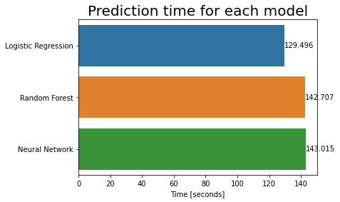

```python
x = sorted([logit_time, rf_time, nn_time])
ax = sb.barplot(x = x, y = ["Logistic Regression","Random Forest","Neural Network"])
plt.xlabel('Time [seconds]')
plt.title('Prediction time for each model', fontsize = 20)
ax.bar_label(ax.containers[0]);
```

## Conclusiones finales

Habiendo analizado el dataset, se procesó de manera tal que se obtuvieron tres modelos con accuracy superior a 0.92. Además, se logró crear una función que permitirá hacer predicciones de noticias nuevas. Esto implica que se alacanzaron los objetivos propuestos.

**Análisis y preprocesado**

**Procesamiento del texto**  
Se crearon matrices TFIDF tanto para el título como para el cuerpo de cada una de las noticias. Se ha combinado el uso de varias librerías diferentes para procesar el texto, tokenizar(nltk) y lematizar(Spacy). Esto ha mostrado llevar a buenos resultados para los algoritmos de ML y DL.

**Feature Engineering**  
Se incorporaron diferentes variables al dataset para facilitar el aprendizaje de los algoritmos. Hay algunos puntos que se presentan como relevantes y relativamente distintivos para este trabajo:

- La inclusión de la longitud del texto procesado (y no del texto raw) tanto del título como del cuerpo de la noticia.
- La manera específica de considerar outliers comparando las distribuciones de fake news y non fake news permitió contribuir positivamente al balanceo de las distribuciones de longitud de texto y título procesado para desfavorecer sesgos en las predicciones de los algortimos.
- Análisis de sentimiento para título y texto de cada noticia.
- Spellcheck de las palabras después de convertir a minúsculas, quitar signos de puntuación y tokenizar, tanto para título como para texto, de cada noticia.

Todos estos factores juntos han permitido crear una matriz X de features que según se mostró en el desarrollo, permitió a los algoritmos de ML y DL obtener buenos resultados.

**Modelos elegidos**

Sobre los **resultados obtenidos** los mismos se consideran satisfactorios, atendiendo al hecho de que el *accuracy* para todos los modelos elegidos es de 0.94. Continuando con el análisis de la *matriz de confusión* para cada modelo, se observa que:

1. la *regresión logística* es bastante homogénea, dando todos los valores en 0.94, con excepción de la **precisión** para *fake news* que es 0.93.
2. la *red neuronal* aumenta la **precisión** en *non fake news* hasta 0.96, aunque comprometiendo la misma en *fake news* en 0.92. El **recall** es 0.96 para *fake news* y 0.92 para *non fake news*.
3. el *bosque aleatorio* entrega **precisión** de 0.94 tanto para *fake* como para *non fake news*, aumentando el **recall** para *non fake* a 0.95 pero comprometiendolo para *fake* en 0.93.

Sobre los **tiempos de entrenamiento**, vale decir que la *red nueronal* supuso muchas más iteraciones que el resto de los modelos. Esto fue principalmente porque la forma de optimización, si bien sigue las pautas vistas durante el curso, no es estructurada o directa. Esto, si bien brinda un gran margen de maniobra, también supone realizar muchos experimentos. Por otro lado, el *BosqueAleatorio* tomó mucho más tiempo que el resto de los otros dos modelos en ser obtenido, por el tiempo de cómputo. Comparando los resultados obtenidos de los tres modelos, la *regresión logística* parece el que mejor atiende a la simplicidad de creación y optimización.

Sobre el **fine tuning** de los modelos vale decir que la *red neuronal* supuso un proceso iterativo mucho más extenso dada la cantidad de variables que son suceptibles de brindar mejoras al modelo. Si bien a los fines de este trabajo se considera satisfactorio el resultado obtenido, se asume que la red podría mejorar aún más, dado que la actual es bastante simple.  
Una vez obtenida y optimizada, la *regresión logística* obtiene resultados similares a la red neuronal presentada. Dada la simplicidad de obtención y los buenos resultados obtenidos este modelo se presenta como el que mejor equilibra "complejidad", "eficacia", y "eficiencia".

El bosque aleatorio no logró superar significativamente a la regresión logística ni a la red neuronal. Esto se dice en el contexto de este trabajo. Bien podrían aumentarse la cantidad de iteraciones en el RandomSearch y luego en el GridSearch. Sin embargo, de los múltiples experimentos llevados a cabo, se han presentado los mejores resultados.

## Anexo

### Imports and functions

```python
# all needed imports are in this cell

# imports libraries
import pandas as pd
import numpy as np
import matplotlib.pyplot as plt
import seaborn as sb
import scipy as sp
import time
import random
import warnings
import pickle
import csv
import sys
csv.field_size_limit(sys.maxsize)

# imports text proc.
import nltk
from nltk.corpus import stopwords
from nltk import word_tokenize
from textblob import TextBlob
from textblob import Word
import spacy
from wordcloud import WordCloud
nltk.download('punkt')
nltk.download('stopwords')
nlp = spacy.load('en_core_web_sm', disable=['parser', 'ner']) # loading spacy lemmatizer

# imports tensorflow
import tensorflow as tf
from tensorflow import keras
from tensorflow.keras import layers
from tensorflow.keras import optimizers

# imports sklearn
from sklearn.feature_extraction.text import TfidfVectorizer
from sklearn.preprocessing import Normalizer
from sklearn.model_selection import train_test_split
from sklearn.metrics import f1_score, confusion_matrix
from sklearn.metrics import classification_report
from sklearn.model_selection import KFold
from sklearn.model_selection import cross_val_score
from sklearn.model_selection import GridSearchCV, RandomizedSearchCV
from sklearn.linear_model import LogisticRegression
from sklearn.tree import DecisionTreeClassifier
from sklearn.naive_bayes import GaussianNB
from sklearn.ensemble import RandomForestClassifier
from sklearn import metrics

# google drive
from google.colab import drive
drive.mount('/content/drive')
```

```python
# functions: all used functions are in this cell save but the prediction function

def minusculas(texto):
  """Takes in a string texto, returns string min_list with all characters to lower"""

  min_list = texto.lower()
  return min_list

def tokenize(texto):
  """Takes in a string texto, returns list token_list with all tokenized words"""

  tokens_list = word_tokenize(texto)
  return tokens_list

def quitar_stopwords(tokens):
    """Takes in a tokens list tokens, returns list filtered_sentence without english stopwords"""

    stop_words = set(stopwords.words('english'))
    filtered_sentence = [w for w in tokens if not w in stop_words]
    return filtered_sentence

def quitar_puntuacion(tokens):
    """Takes in a tokens list tokens, returns list words excluding all but alphanumerical characters"""

    words=[word for word in tokens if word.isalnum()]
    return words

def lematizar(tokens):
    """Takes in a list tokens, returns a string mytokens with all of the words lemmatized

    Tokens are joint in a string, thereafter lemmatized and lowercased.
    """

    sentence = " ".join(tokens)
    mytokens = nlp(sentence)
    mytokens = [ word.lemma_ if word.lemma_ != "-PRON-" else word.lower_ for word in mytokens ]
    return mytokens

def func(word):
    """Takes in a string word, returns the confidence from the first spellcheck tuple (word, confidence)

    Requires TextBlob
    """

    a = Word(word)
    w = a.spellcheck()
    c = w[0][1]
    return c

def spellcheck(row_list):
    """Takes in a list row_list, returns the mean of the confidence from the first spellcheck tuple (word, confidence) for each word in row_list

    Uses a predefined function func.
    """

    if len(row_list) == 0:
        return np.NaN
    else:
        random.seed(a = 1)
        lng = len(row_list)
        sample_list = random.sample(row_list, int(round(lng*0.1)))
        confidencias = list(map(func, sample_list))
        mean = np.mean(confidencias)
    return mean

def plot_word_cloud(terms):
    """Plots wordcloud of terms"""

    text = terms.index
    text = ' '.join(list(text))
    wordcloud = WordCloud(max_font_size=40).generate(text)
    plt.figure(figsize=(25, 25))
    plt.imshow(wordcloud, interpolation="bilinear")
    plt.axis("off")
    plt.show()

def convert_sparse_matrix_to_sparse_tensor(X):
    """Takes in sparse matrix X, returns sparse tensor"""

    coo = X.tocoo()
    indices = np.mat([coo.row, coo.col]).transpose()
    return tf.SparseTensor(indices, coo.data, coo.shape)

def plot_history(fitting):
    """Takes in fitted neuronal network model fitting, returns plotted training and validation accuracy and loss vs number of epochs"""

    acc = fitting.history['accuracy']
    val_acc = fitting.history['val_accuracy']
    loss = fitting.history['loss']
    val_loss = fitting.history['val_loss']
    x = range(1, len(acc) + 1)
    plt.figure(figsize=(12, 5))
    plt.subplot(1, 2, 1)
    plt.plot(x, acc, 'b', label='Training acc')
    plt.plot(x, val_acc, 'r', label='Validation acc')
    plt.title('Training and validation accuracy')
    plt.legend()
    plt.subplot(1, 2, 2)
    plt.plot(x, loss, 'b', label='Training loss')
    plt.plot(x, val_loss, 'r', label='Validation loss')
    plt.title('Training and validation loss')
    plt.legend()

def model_evaluation(models, score, X, y):
    """Compares score for models.

    Parameters
    ----------
    models: list
      list of models to evaluate
    score: string
      the score to be used to perform the comparisson
    X: array
      array of features
    y: array
      labels or target vector for X

    Returns
    -------
    Accuracy and KFold for each model

    """

    results = []
    names = []
    # for each model
    for name, model in models:
        warnings.filterwarnings('ignore')
        # KFold is created
        KF = KFold(n_splits = 10, shuffle = True, random_state = 98)

        # cross validation
        cv_results = cross_val_score(model, X, y, cv = KF, scoring = score, verbose = False)

        # storing the results
        results.append(cv_results)
        names.append(name)

        # printing the results
        print('Metric: {} , KFold '.format(str(score)))
        print("%s: %f (%f) " % (name, cv_results.mean(), cv_results.std()))

    return results, names

def evaluate(model, test_features, test_labels):
    """Takes in model, test features and test labels, returns confusion matrix and classification report."""

    y_pred = model.predict(test_features)
    print('Model Performance')
    print(confusion_matrix(y_test,y_pred))
    print(classification_report(y_test,y_pred))
```

#### Función de predicción *predict*

```python
# prediction function
def predict(pr, model):
  pr.fillna('missing', inplace = True)
  pr.replace({'nan':'missing'}, inplace = True)
  #tr_m = None
  csv.field_size_limit(sys.maxsize)
  tr_m = pd.read_csv('/content/drive/MyDrive/preprocessed_train.csv', engine = "python", encoding='utf-8') # looading the dataset in the variable tr
  #tr_m.fillna(1, inplace = True)
  warnings.filterwarnings('ignore')

  nlp = spacy.load('en_core_web_sm', disable=['parser', 'ner']) # loading spacy lemmatizer

  # preprocessing news's text
  text_tkn = [minusculas(i) for i in pr['text']] # lowercase news's text
  text_tkn = [tokenize(i) for i in text_tkn] # tokenize news's text
  text_tkn = [quitar_stopwords(i) for i in text_tkn] # removing stopwords from news's text
  text_tkn = [quitar_puntuacion(i) for i in text_tkn] # removing all but alphanumerical characters from news's text

  # adding the processed text column to the dataset
  pr['txt_preproc'] = text_tkn

  # adding preprocessed news's text length column
  length = list()
  for i in range(len(pr)):
    length.append(len(pr.txt_preproc[i]))
  pr['length_proc'] = length

  # adding news's text length column
  length = list()
  for i in range(len(pr)):
    length.append(len(pr.text[i]))
  pr['length'] = length

  # preprocessing news's title
  title_tkn = [minusculas(i) for i in pr['title']] # lowercase the news's title
  title_tkn = [tokenize(i) for i in title_tkn] # tokenize the news's title
  title_tkn = [quitar_stopwords(i) for i in title_tkn] # removing news's stopwords
  title_tkn = [quitar_puntuacion(i) for i in title_tkn] # remvoving all but alphanumeric characters from news's title

  # adding the processed title column to the dataset
  pr['ttl_preproc'] = title_tkn

  # adding processed title length column to the dataset
  title_length = list()
  for i in range(len(pr)):
    title_length.append(len(pr['ttl_preproc'][i]))
  pr['length_ttl'] = title_length

  # subjectivity and polarity for news's title
  ttl_subjectivity = pr['title'].apply(lambda x: TextBlob(x).sentiment.subjectivity)
  ttl_polarity = pr['title'].apply(lambda x: TextBlob(x).sentiment.polarity)

  # subjectivity and polarity for news's text
  txt_subjectivity = pr['text'].apply(lambda x: TextBlob(x).sentiment.subjectivity)
  txt_polarity = pr['text'].apply(lambda x: TextBlob(x).sentiment.polarity)

  # adding the features to the dataset
  pr['ttl_subjectivity'] = ttl_subjectivity
  pr['ttl_polarity'] = ttl_polarity
  pr['txt_subjectivity'] = txt_subjectivity
  pr['txt_polarity'] = txt_polarity

  nlp = spacy.load('en_core_web_sm', disable=['parser', 'ner']) # loading spacy lemmatizer
  txt_lemm = pr.txt_preproc.apply(lematizar) # lemmatizing the news's text applying the function lematizar
  ttl_lemm = pr.ttl_preproc.apply(lematizar) # lemmatizing the news's title applying the function lematizar
  pr['ttl_lemm'] = ttl_lemm # adding the lemmatized title feature to the dataset
  pr['txt_lemm'] = txt_lemm # adding the lemmatized text feature to the dataset

  txt_spellcheck = pr.txt_preproc.apply(spellcheck) # applying the spellcheck to the preprocessed text_tkn
  pr['txt_spellcheck'] = txt_spellcheck # adding the text spellcheck feature to the dataset
  ttl_spellcheck = pr.ttl_preproc.apply(spellcheck) # applying the spellcheck to the preprocessed title
  pr['ttl_spellcheck'] = ttl_spellcheck # adding the title spellcheck feature to the dataset
  pr.txt_spellcheck.fillna(1, inplace = True)
  pr.ttl_spellcheck.fillna(1, inplace = True)

  # transforming lemmatized lists features to strings
  #pr.reset_index(drop=True, inplace = True)
  pr['txt_lema'] = [" ".join(pr['txt_lemm'][x]) for x in range(len(pr['txt_lemm']))]
  pr['ttl_lema'] = [" ".join(pr['ttl_lemm'][x]) for x in range(len(pr['ttl_lemm']))]
  #tr_m.reset_index(drop= True, inplace = True)
  #tr_m['txt_lema'] = [" ".join(tr_m['txt_lemm'][x]) for x in range(len(tr_m['txt_lemm']))]
  #tr_m['ttl_lema'] = [" ".join(tr_m['ttl_lemm'][x]) for x in range(len(tr_m['ttl_lemm']))]

  # appending base dataset to the dataset to be predicted
  tr_m_toappend = tr_m[pr.columns].copy()
  pr_vec = pd.concat([tr_m_toappend, pr], ignore_index=True)

  # vectorizing text
  vectorizador_txt = TfidfVectorizer(min_df = 0.05, ngram_range = (1,4), max_df = 0.85, max_features = 4000)
  vector_txt = vectorizador_txt.fit_transform(pr_vec['txt_lema'].values.astype('U'))

  # vectorizing title
  vectorizador_ttl = TfidfVectorizer(min_df = 0.00, ngram_range = (1,4), max_df = 1, max_features = 1000)
  vector_ttl = vectorizador_ttl.fit_transform(pr_vec['ttl_lema'].values.astype('U'))

  # features to add to the model
  extra_features = pr_vec[[
    'length_proc','length_ttl',
    'ttl_subjectivity','ttl_polarity','txt_subjectivity', 'txt_polarity',
    'txt_spellcheck','ttl_spellcheck']]

  X = sp.sparse.hstack((vector_txt,vector_ttl,extra_features.values),format='csr') # building the feature matrix X

  # variable ind to slice the rows to be predicted
  start = tr_m.shape[0]
  end = X.shape[0]
  ind = np.arange(start,end)
  slc = slice(start, end, 1)

  if model == "logistic_regression":
    filename = 'lr.sav'
    path = F"/content/drive/My Drive/{filename}"
    logistic_regression = pickle.load(open(path,'rb'))
    y_pred = logistic_regression.predict(X[ind,:])
  elif model == "randomforest":
    filename = 'rf.sav'
    path = F"/content/drive/My Drive/{filename}"
    randomforest = pickle.load(open(path,'rb'))
    y_pred = randomforest.predict(X[ind,:])
  elif model == "neural_network":
    X = convert_sparse_matrix_to_sparse_tensor(X)
    X = tf.sparse.to_dense(X, default_value=None, validate_indices=True, name=None)
    neural_network = tf.keras.models.load_model("/content/drive/My Drive/NN")
    y_pred = neural_network.predict(X[slc,:]).round()

  pr['prediction'] = y_pred
  return pr[['author', 'title', 'text','prediction']]
```

### Primer Análisis

```python
tr = pd.read_csv('/content/drive/MyDrive/train.csv', engine = "python", encoding='utf-8') # looading the dataset in the variable tr
```

```python
print("Shpae is:", tr.shape)
```

```
Shpae is: (20800, 5)
```

```python
tr.info()
```

```
<class 'pandas.core.frame.DataFrame'>
RangeIndex: 20800 entries, 0 to 20799
Data columns (total 5 columns):
 #   Column  Non-Null Count  Dtype
---  ------  --------------  -----
 0   id      20800 non-null  int64
 1   title   20242 non-null  object
 2   author  18843 non-null  object
 3   text    20761 non-null  object
 4   label   20800 non-null  int64
dtypes: int64(2), object(3)
memory usage: 812.6+ KB
```

```python
print("Value counts for each label:\n",tr.label.value_counts())
```

```
Value counts for each label:
 1    10413
0    10387
Name: label, dtype: int64
```

```python
tr.fillna('missing', inplace = True) # creating a category "missing" for NaN to be a candidate feature variable
```

```python
print("Value counts for missing title for each label:\n",tr.query('title == "missing"').label.value_counts())
```

```
Value counts for missing title for each label:
 1    558
Name: label, dtype: int64
```

```python
print("Value counts for missing author for each label:\n",tr.query('author == "missing"').label.value_counts())
```

```
Value counts for missing author for each label:
 1    1931
0      26
Name: label, dtype: int64
```

```python
print("Value counts for text missing for each label:\n",tr.query('text == "missing"').label.value_counts())
```

```
Value counts for text missing for each label:
 1    39
Name: label, dtype: int64
```

```python
print("Value counts for news with missing title and text:\n",tr[(tr.text == 'missing') & (tr.title == 'missing')].value_counts())
```

```
Value counts for news with missing title and text:
 Series([], dtype: int64)
```

```python
print("Quantity of different authors is:",len(tr.author.unique()))
```

```
Quantity of different authors is: 4202
```

#### Removiendo Duplicados

```python
# news are considered duplicated if title, author, text and label are the same
print("Quantity of duplicated news is:",sum(tr[['title','author','text','label']].duplicated()))
```

```
Quantity of duplicated news is: 109
```

```python
tr.drop_duplicates(subset = ['title','author','text'], inplace = True) # dropping duplicates from dataset
sum(tr[['title','author','text','label']].duplicated()) # veryfying dropping operation succeeded
```

```
0
```

### Wordclouds

```python
# transforming lemmatized lists features to strings
tr.reset_index(drop= True, inplace = True)
tr['txt_lema'] = [" ".join(tr['txt_lemm'][x]) for x in range(len(tr['txt_lemm']))]
tr['ttl_lema'] = [" ".join(tr['ttl_lemm'][x]) for x in range(len(tr['ttl_lemm']))]

# vectorizing news's text and title
vectorizador_txt = TfidfVectorizer(min_df = 0.05, ngram_range = (1,4), max_df = 0.85, max_features = 300)
vector_txt = vectorizador_txt.fit_transform(tr['txt_lema'])

vectorizador_ttl = TfidfVectorizer(min_df = 0.00, ngram_range = (1,4), max_df = 1, max_features = 300)
vector_ttl = vectorizador_ttl.fit_transform(tr['ttl_lema'])

# building dataframe with the most important words to plot for news's text and title
txt_tfidf_dict = dict(zip(vectorizador_txt.get_feature_names_out(), vectorizador_txt.idf_))
txt_tfidf = pd.DataFrame(columns=['tfidf']).from_dict(dict(txt_tfidf_dict), orient = 'index')

ttl_tfidf_dict = dict(zip(vectorizador_ttl.get_feature_names_out(), vectorizador_ttl.idf_))
ttl_tfidf = pd.DataFrame(columns=['tfidf']).from_dict(dict(ttl_tfidf_dict), orient = 'index')
```

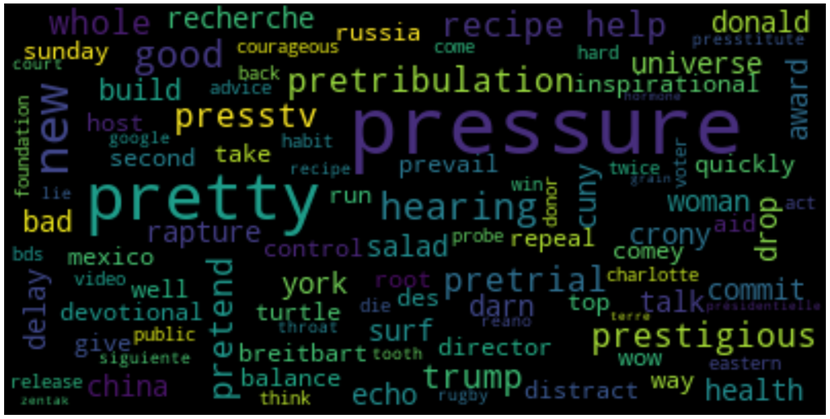

```python
plot_word_cloud(ttl_tfidf.sort_values(by = [0], ascending=True).head(100))
```

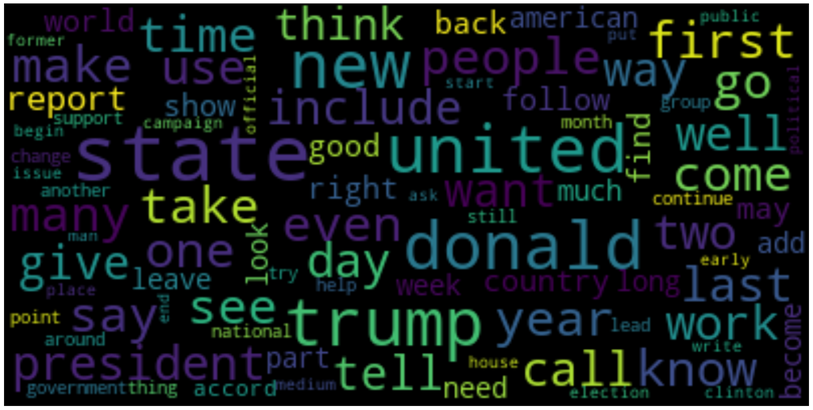

```python
plot_word_cloud(txt_tfidf.sort_values(by = [0], ascending=True).head(100))
```

### Manejo de outliers para text length

#### Preprocesamiento del cuerpo de la noticia. Agregado de features.

```python
# preprocessing news's text
text_tkn = [minusculas(i) for i in tr['text']] # lowercase news's text
text_tkn = [tokenize(i) for i in text_tkn] # tokenize news's text
text_tkn = [quitar_stopwords(i) for i in text_tkn] # removing stopwords from news's text
text_tkn = [quitar_puntuacion(i) for i in text_tkn] # removing all but alphanumerical characters from news's text

# adding the processed text column to the dataset
tr['txt_preproc'] = text_tkn

# adding preprocessed news's text length column
tr.reset_index(inplace = True)
length = list()
for i in range(len(tr.txt_preproc)):
  length.append(len(tr.txt_preproc[i]))
tr['length_proc'] = length

# adding news's text length column
length = list()
for i in range(len(tr)):
  length.append(len(tr.text[i]))
tr['length'] = length
```

##### Plots y Outliers de Text Length

Se observa que las distribuciones de length para fake y non fake no son parejas para valores mayores que el bigote.  
Para evitar sesgos en el modelo, se busca emparejar las distribuciones.

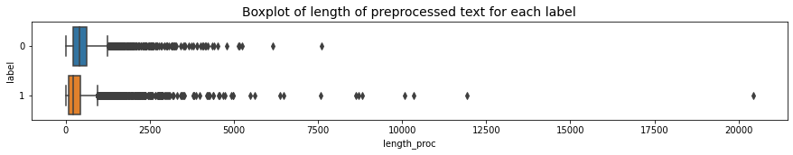

```python
sb.boxplot(x = "length_proc", y = "label", data = tr, orient = "h")
plt.title("Boxplot of length of preprocessed text for each label",fontdict={'fontsize':14})
plt.gcf().set_size_inches(15, 2)
```

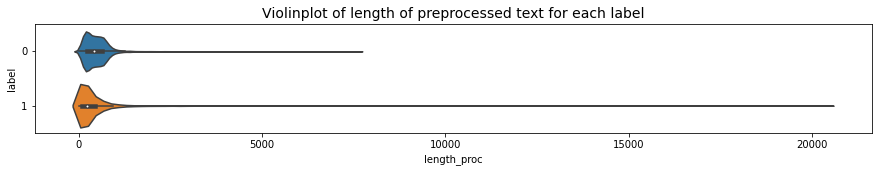

```python
sb.violinplot(x = "length_proc", y = "label", data = tr, orient = "h")
plt.title("Violinplot of length of preprocessed text for each label",fontdict={'fontsize':14})
plt.gcf().set_size_inches(15, 2)
```

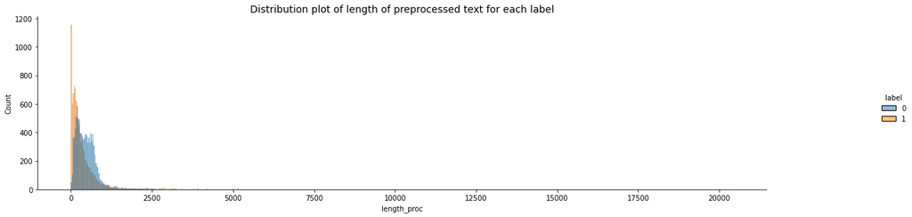

```python
p = sb.displot(x = "length_proc", data = tr, hue = "label")
plt.title("Distribution plot of length of preprocessed text for each label",fontdict={'fontsize':14})
plt.gcf().set_size_inches(20, 4)
```

###### Análisis de la longitud del texto preprocesado

Exploración de la cantidad de outliers según la regla del boxplot.  
Con esta información se decidirá que valor usar como cota superior para eliminar outliers.

```python
print("Length of preprocessed news's text for fake news: \n",tr.query('label == 1')['length_proc'].describe())
```

```
Length of preprocessed news's text for fake news:
 count    10304.000000
mean       351.999224
std        534.992244
min          0.000000
25%         97.000000
50%        218.000000
75%        434.000000
max      20426.000000
Name: length_proc, dtype: float64
```

```python
q1_1 = np.percentile(tr.query('label == 1')['length_proc'],25) # first quartile for fake news
q3_1 = np.percentile(tr.query('label == 1')['length_proc'],75) # third quartile for fake news

# amount of fake news with preprocessed text length greater than boxplot whiskers
outofw = len(tr[(tr['label'] == 1) & (tr['length_proc'] >= q3_1 + 1.5*(q3_1-q1_1))])

count1 = len(tr.query('label == 1')['length_proc'])
count = len(tr)

print("Fake news boxplot outliers vs number of fake news: ", outofw / count1)
print("Fake news boxplot outliers vs total number of news: ", outofw / count)
```

```
Fake news boxplot outliers vs number of fake news:  0.06531444099378882
Fake news boxplot outliers vs total number of news:  0.03252621912908994
```

```python
print("Length of preprocessed news's text for NON fake news: \n",tr.query('label == 0')['length_proc'].describe())
```

```
Length of preprocessed news's text for NON fake news:
 count    10387.000000
mean       478.268027
std        389.645078
min          0.000000
25%        227.000000
50%        421.000000
75%        639.000000
max       7613.000000
Name: length_proc, dtype: float64
```

```python
q1_0 = np.percentile(tr.query('label == 0')['length_proc'],25)
q3_0 = np.percentile(tr.query('label == 0')['length_proc'],75)

# amount of NON fake news with preprocessed text length greater than boxplot whiskers
outofw = len(tr[(tr['label'] == 0) & (tr['length_proc'] >= q3_0 + 1.5*(q3_0-q1_0))])

count0 = len(tr.query('label == 0')['length_proc'])
count = len(tr)

print("NON fake news boxplot outliers vs number of NON fake news: ", outofw / count0)
print("NON fake news boxplot outliers vs total number of news: ", outofw / count)
```

```
NON fake news boxplot outliers vs number of NON fake news:  0.02618657937806874
NON fake news boxplot outliers vs total number of news:  0.01314581218887439
```

Visualización de la posición relativa de cada uno de los bigotes.

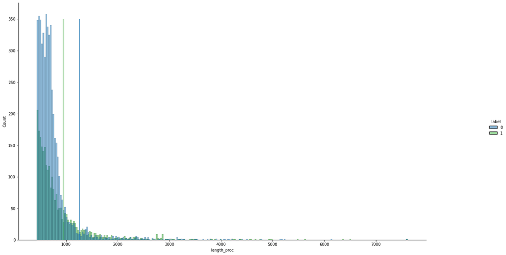

```python
max0 = max(tr.query('label == 0')['length_proc'])
q = np.percentile(tr.query('label == 1')['length_proc'],75)
data = tr[(tr['length_proc'] >= q) & (tr['length_proc'] <= max0)]

p = sb.displot(x = "length_proc", data = data, hue = "label", palette = ('C0', 'C2'))
plt.vlines(x = q3_0 + 1.5*(q3_0-q1_0), ymin = 0, ymax = 350, colors = 'C0')
plt.vlines(x = q3_1 + 1.5*(q3_1-q1_1), ymin = 0, ymax = 350, colors = 'C2')

plt.gcf().set_size_inches(20, 10)
```

El valor más alto será utilizado como cota superior para dividir outliers.  
Todas las noticias cuya longitud de texto preprocesado sea mayor que el valor tomado como cota superior será eliminado por ser outlier.  
Pero primero, se comprobará que los outliers no sean mas del 5% del dataset.

```python
whisk0 = q3_0 + 1.5*(q3_0-q1_0) # the greatest whisker is for NON fake news

# total news with preprocessed text length greater than the greatest whisker
outofw = len(tr.query('length_proc >= @whisk0'))

# total NON fake news with preprocessed text length greater than the greatest whisker
outofw0 = len(tr[(tr['label'] == 0) & (tr['length_proc'] >= whisk0)])

# total fake news with preprocessed text length greater than the greatest whisker
outofw1 = len(tr[(tr['label'] == 1) & (tr['length_proc'] >= whisk0)])

count0 = len(tr.query('label == 0')['length_proc']) # total NON fake news
count1 = len(tr.query('label == 1')['length_proc']) # total fake news
count = len(tr) # total news

print("Total outliers vs total news: ", outofw/count)
print("Total NON fake news outliers vs total NON fake news: ", outofw0/count0)
print("Total fake news outliers vs total fake news: ", outofw1/count1)
```

```
Total outliers vs total news:  0.03025470011115944
Total NON fake news outliers vs total NON fake news:  0.02618657937806874
Total fake news outliers vs total fake news:  0.0343555900621118
```

##### Eliminación de outliers y visualización de las distribuciones emparejadas.

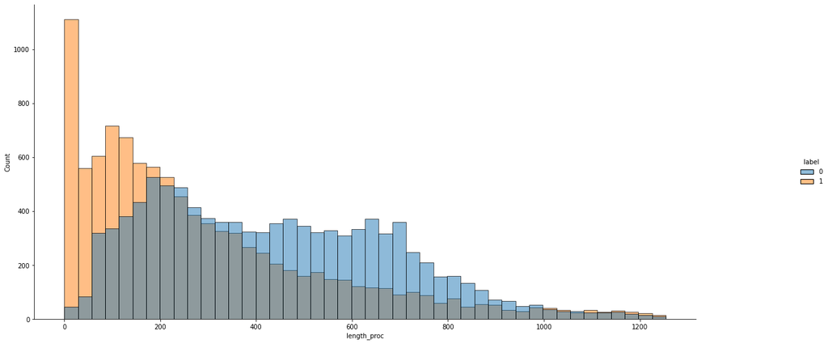

```python
cut = whisk0
tr = tr.query('length_proc <= @cut').copy().reset_index()
p = sb.displot(x = "length_proc", data = tr, hue = "label")
plt.gcf().set_size_inches(20, 8)
```

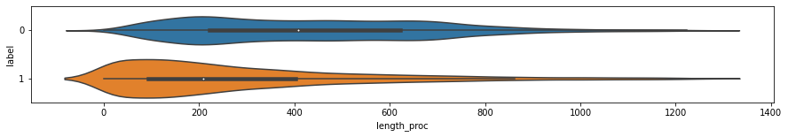

```python
sb.violinplot(x = "length_proc", y = "label", data = tr, orient = "h")
plt.gcf().set_size_inches(15, 2)
```

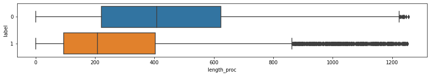

```python
sb.boxplot(x = "length_proc", y = "label", data = tr, orient = "h")
plt.gcf().set_size_inches(15, 2)
```

### Manejo de outliers para title length

#### Preprocesamiento del título de la noticia. Agregado de features.

```python
# preprocessing news's title
title_tkn = [minusculas(i) for i in tr['title']] # lowercase the news's title
title_tkn = [tokenize(i) for i in title_tkn] # tokenize the news's title
title_tkn = [quitar_stopwords(i) for i in title_tkn] # removing news's stopwords
title_tkn = [quitar_puntuacion(i) for i in title_tkn] # remvoving all but alphanumeric characters from news's title

# adding the processed title column to the dataset
tr['ttl_preproc'] = title_tkn

# adding processed title length column to the dataset
title_length = list()
for i in range(len(tr)):
    title_length.append(len(tr['ttl_preproc'][i]))
tr['length_ttl'] = title_length
```

##### Plots y Outliers de Title length

Se observa que las distribuciones no son parejas.  
Se buscará definir una cota superior para delimitar outliers.

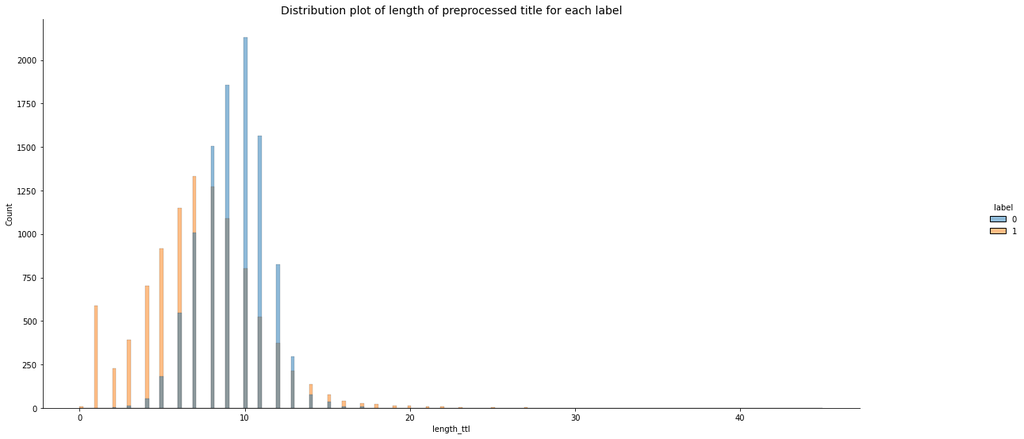

```python
p = sb.displot(x = "length_ttl", data = tr, hue = "label")
plt.title("Distribution plot of length of preprocessed title for each label",fontdict={'fontsize':14})
plt.gcf().set_size_inches(20, 8)
```

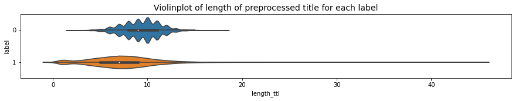

```python
sb.violinplot(x = "length_ttl", y = "label", data = tr, orient = "h")
plt.title("Violinplot of length of preprocessed title for each label",fontdict={'fontsize':14})
plt.gcf().set_size_inches(15, 2)
```

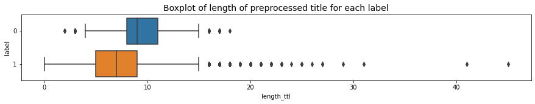

```python
sb.boxplot(x = "length_ttl", y = "label", data = tr, orient = "h")
plt.title("Boxplot of length of preprocessed title for each label",fontdict={'fontsize':14})
plt.gcf().set_size_inches(15, 2)
```

```python
print("Length of preprocessed news's title for fake news: \n", tr.query('label == 1')['length_ttl'].describe())
```

```
Length of preprocessed news's title for fake news:
 count    9950.000000
mean        7.304221
std         3.418687
min         0.000000
25%         5.000000
50%         7.000000
75%         9.000000
max        45.000000
Name: length_ttl, dtype: float64
```

```python
print("Length of preprocessed news's title for NON fake news: \n", tr.query('label == 0')['length_ttl'].describe())
```

```
Length of preprocessed news's title for NON fake news:
 count    10115.000000
mean         9.333663
std          1.960478
min          2.000000
25%          8.000000
50%          9.000000
75%         11.000000
max         18.000000
Name: length_ttl, dtype: float64
```

El valor máximo de NON Fake News será utilizado como cota superior para delimitar outliers.  
Todos los datos cuya longitud de título preprocesado sea mayor que esta cota serán eliminados por ser outliers.

```python
max1 = max(tr.query('label == 0')['length_ttl'])
max1, len(tr.query('length_ttl > @max1'))
```

```
(18, 53)
```

##### Eliminación de outliers y visualización de distribuciones emparejadas.

```python
max1 = max(tr.query('label == 0')['length_ttl'])
tr = tr.query('length_ttl <= @max1').copy()
```

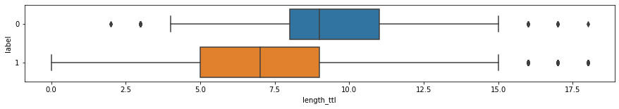

```python
sb.boxplot(x = "length_ttl", y = "label", data = tr, orient = "h")
plt.gcf().set_size_inches(15, 2)
```

### Sentiment Analysis Plots

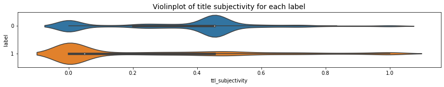

```python
sb.violinplot(x = "ttl_subjectivity", y = "label", data = tr, orient = "h")
plt.title("Violinplot of title subjectivity for each label",fontdict={'fontsize':14})
plt.gcf().set_size_inches(15, 2)
```

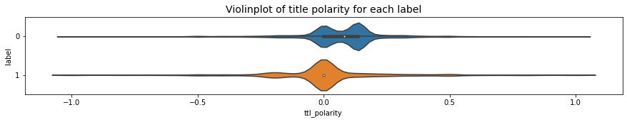

```python
sb.violinplot(x = "ttl_polarity", y = "label", data = tr, orient = "h")
plt.title("Violinplot of title polarity for each label",fontdict={'fontsize':14})
plt.gcf().set_size_inches(15, 2)
```

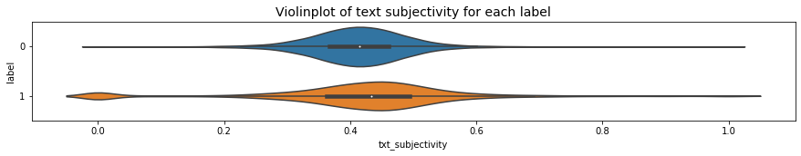

```python
sb.violinplot(x = "txt_subjectivity", y = "label", data = tr, orient = "h")
plt.title("Violinplot of text subjectivity for each label",fontdict={'fontsize':14})
plt.gcf().set_size_inches(15, 2)
```

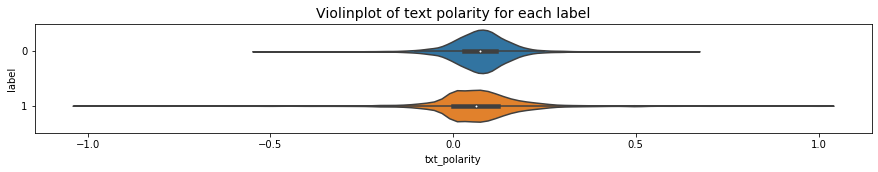

```python
sb.violinplot(x = "txt_polarity", y = "label", data = tr, orient = "h")
plt.title("Violinplot of text polarity for each label",fontdict={'fontsize':14})
plt.gcf().set_size_inches(15, 2)
```

### Nulos

```python
tr[[
    'length_proc','length_ttl',
    'ttl_subjectivity','ttl_polarity','txt_subjectivity', 'txt_polarity',
    'txt_spellcheck','ttl_spellcheck']].isna().sum()
```

```
length_proc            0
length_ttl             0
ttl_subjectivity       0
ttl_polarity           0
txt_subjectivity       0
txt_polarity           0
txt_spellcheck       257
ttl_spellcheck      3085
dtype: int64
```

Solo se ven nulos en los spellchecks. Basándose en el análisis exploratorio anteriormente realizado, NAs se completan con 1, la confianza más alta.

```python
tr.fillna(1, inplace = True)
```

```python
tr[[
    'length_proc','length_ttl',
    'ttl_subjectivity','ttl_polarity','txt_subjectivity', 'txt_polarity',
    'txt_spellcheck','ttl_spellcheck']].isna().sum()
```

```
length_proc         0
length_ttl          0
ttl_subjectivity    0
ttl_polarity        0
txt_subjectivity    0
txt_polarity        0
txt_spellcheck      0
ttl_spellcheck      0
dtype: int64
```

### Random Search para Random Forest

```python
# Number of trees in random forest
n_estimators = [int(x) for x in np.linspace(start = 200, stop = 2000, num = 10)]
max_features = ['auto', 'sqrt'] # Number of features to consider at every split

# Maximum number of levels in tree
max_depth = [int(x) for x in np.linspace(10, 110, num = 11)]
max_depth.append(None)
min_samples_split = [2, 5, 10] # Minimum number of samples required to split a node
min_samples_leaf = [1, 2, 4] # Minimum number of samples required at each leaf node
bootstrap = [True, False] # Method of selecting samples for training each tree

# random grid
random_grid = {'n_estimators': n_estimators,'max_features': max_features,'max_depth': max_depth,
               'min_samples_split': min_samples_split,'min_samples_leaf': min_samples_leaf,'bootstrap': bootstrap}

# searching for hyperparameters
rf = RandomForestClassifier()
rf_random = RandomizedSearchCV(estimator = rf, param_distributions = random_grid,
                               n_iter = 4, cv = 4, verbose=1, random_state=42, n_jobs = -1)

rf_random.fit(X_train, y_train) # fitting the model
best_random = rf_random.best_estimator_
grid_accuracy = evaluate(best_random, X_test, y_test) # evaluating for the best estimator
```

```
Fitting 4 folds for each of 4 candidates, totalling 16 fits
Model Performance
[[2420  142]
 [ 153 2288]]
              precision    recall  f1-score   support

         0.0       0.94      0.94      0.94      2562
         1.0       0.94      0.94      0.94      2441

    accuracy                           0.94      5003
   macro avg       0.94      0.94      0.94      5003
weighted avg       0.94      0.94      0.94      5003
```

### Almacenado Persistente de los Modelos

```python
# saving neural network model
!mkdir -p saved_model
nn_model.save("/content/drive/My Drive/NN")
```

```python
# saving randomforest stored in variable best_grid
filename = 'rf.sav'
path = F"/content/drive/My Drive/{filename}"
pickle.dump(best_grid, open(path,'wb'))
```

```python
# saving logistic regression stored in variable in lr
filename = 'lr.sav'
path = F"/content/drive/My Drive/{filename}"
pickle.dump(lr, open(path,'wb'))
```

### Comparación de tiempos de predicciones

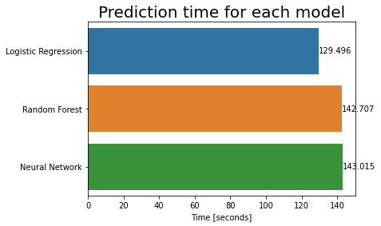

```python
x = sorted([logit_time, rf_time, nn_time])
ax = sb.barplot(x = x, y = ["Logistic Regression","Random Forest","Neural Network"])
plt.xlabel('Time [seconds]')
plt.title('Prediction time for each model', fontsize = 20)
ax.bar_label(ax.containers[0]);
```